# Next Word Generator Sales Pitch

2022-12-05

## Sales Pitch for the Next Word Generator

The final capstone of the Data Science Specialization course by John Hopkins University through Coursera is to build an app which generates words based on user input.

The app need to be scaled to run in a Shiny app, but effective enough to generate next words based off of n-grams.

The corpa came from SwiftKeys, and consists of Twitter, blogs and news articles.

## Methodology

The corpa were cleaned and restructured into a useable format. Tokens of n-grams were created, and then ranked by frequency they appeared in the corpus.

Originally, there were 2.4 million records in the SwiftKeys corpa, and they were reduced to bigrams, trigrams, and quadgrams.

When the user begins to type, the algorithm starts by trying to match and return a quadgram, and if it does not match, searches for the trigrams, and if it does not match, searches through the bigrams.

## Visual

Here is a screen capture of the Next Word Generator app!

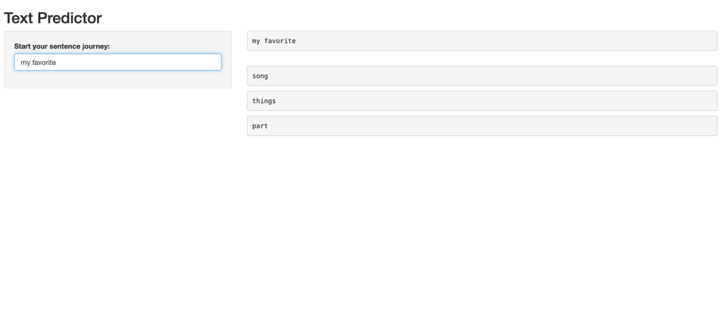

## Links

The link to the Next Word Generator app can be found on [Shinyapps.io](https://rhowell421.shinyapps.io/Next_Word_Generator/)

The link to the code can be found on [GitHub](https://github.com/rhowell421)